# Chapter 4 Plots

Jim Albert

June 8, 2017

### Count Effects

Load in a few helpful packages.

```r
library(readr)
library(ggplot2)
library(dplyr)
```

#### The Data

Using the Retrosheet play-by-play data for the 2015 season, I found the expected runs in the remainder of the inning for plate appearances that pass through each possible count. I store these expected runs values in the csv file “count2015a.csv”.

I read this file into R – variable name of data frame is `d` – and show the first few lines.

```r
d <- read_csv("https://bayesball.github.io/VB/data/count2015a.csv")
head(d)
```

```
## # A tibble: 6 x 6
##   count strikes balls N.Pitches    Type         Runs
##   <chr>   <int> <int>     <int>   <chr>        <dbl>
## 1   0-0       0     0         0 Neutral -0.000798051
## 2   1-0       0     1         1  Batter  0.033855787
## 3   0-1       1     0         1 Pitcher -0.038708814
## 4   2-0       0     2         2  Batter  0.094016898
## 5   1-1       1     1         2 Pitcher -0.015252581
## 6   0-2       2     0         2 Pitcher -0.089381123
```

#### The Graph

In this graph, the Pitch Number (variable `N.Pitches`) is graphed against the Runs Value (variable `Runs`), using the Count (variable `count`) as the plotting label.

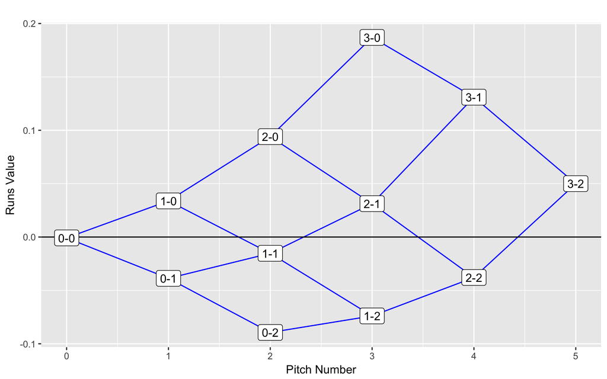

```r
ggplot(d, aes(N.Pitches, Runs, label=count)) +
  geom_point() +
  geom_path(data=filter(d, strikes==0),
     aes(N.Pitches, Runs), color="blue") +
  geom_path(data=filter(d, strikes==1),
     aes(N.Pitches, Runs), color="blue") +
  geom_path(data=filter(d, strikes==2),
     aes(N.Pitches, Runs), color="blue") +
  geom_path(data=filter(d, balls==0),
     aes(N.Pitches, Runs), color="blue") +
  geom_path(data=filter(d, balls==1),
     aes(N.Pitches, Runs), color="blue") +
  geom_path(data=filter(d, balls==2),
     aes(N.Pitches, Runs), color="blue") +
  geom_path(data=filter(d, balls==3),
     aes(N.Pitches, Runs), color="blue") +
  xlab("Pitch Number") +
  ylab("Runs Value") +
  ggtitle("") +
  geom_hline(yintercept=0, color="black") +
  geom_label()
```

#### Data

```r
S <- read_csv("https://bayesball.github.io/VB/data/count2015b.csv")
head(S)
```

```
## # A tibble: 6 x 6
##   count       Runs strikes balls N.Pitches     N
##   <chr>      <dbl>   <int> <int>     <int> <int>
## 1   0-0 0.04020994       0     0         0 20668
## 2   0-1 0.01629339       1     0         1 16560
## 3   0-2 0.01622481       2     0         2  8374
## 4   1-0 0.05057780       0     1         1 12366
## 5   1-1 0.03688532       1     1         2 15601
## 6   1-2 0.01841516       2     1         3 14508
```

#### The Graph

In this graph, the Pitch Number (variable `N.Pitches`) is graphed against the Runs Value (variable `Runs`), using the Count (variable `count`) as the plotting label.

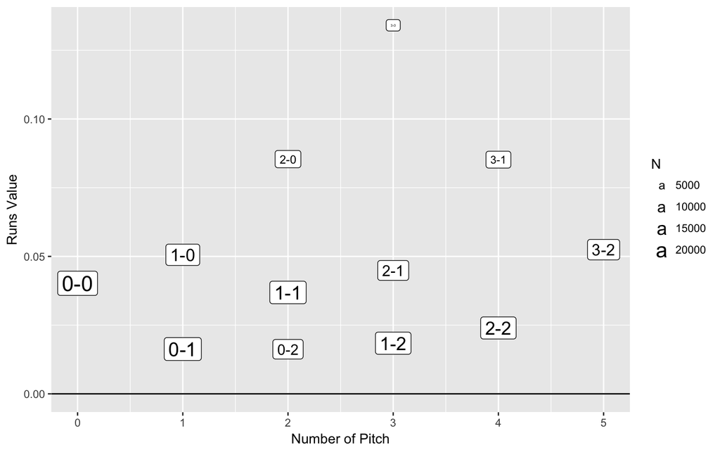

```r
ggplot(S, aes(N.Pitches, Runs, label=count, size=N)) +
  xlab("Number of Pitch") +
  ylab("Runs Value") +
  geom_hline(yintercept=0, color="black") +
  geom_label()
```